# COMP2200/COMP6200: Data Science

## Lecture Week 3

## Agenda

- Data Science methodology and workflow
- Data understanding
- Descriptive statistics
- Start thinking about project

## Data Science methodology

[figure not shown]

Cross-Industry Standard Process for Data Mining (CRISP-DM) is a standardised workflow for Data Mining/Data Science that attempts to lay out a methodology to follow in a project. It is in comparable to software development life cycle.

- As a **methodology**, CRISP-DM includes descriptions of the typical phases of a project, the tasks involved with each phase, and an explanation of the relationships between these tasks.
- As a **process model**, CRISP-DM provides an overview of the data mining life cycle.

## CRISP-DM model is flexible and can be customised

- Example 1: **Detecting money laundering** This task mainly focus on data exploration and visualisation to uncover suspicious patterns in data
- Example 2: [AI-based animal recognition](https://siwalusoftware.com/)

## Methodology

- **Business Understanding** DS problems generally come out of some business need (or maybe from some scientific or humanities research goal). So, understanding why the questions are being asked and how an answer might be used is important.
- **Data Understanding** what data is available, what do the fields mean, what other data sources would we like to be able to access, assessing data quality

## Methodology

- **Data Preparation** and **Modelling** are the core processes we're learning how to do in Python
- **Model Evaluation** how will you know if you've succeeded? Evaluation of the model with respect to business needs - are the predictions accurate enough to help the business?
- **Deployment** is this a one off analysis that generates a report or a model that will be used repeatedly in some kind of production environment? Does it need to be updated as new data becomes available?
- [7 Fundamental Steps to Complete a Data Analytics Project](https://blog.dataiku.com/2019/07/04/fundamental-steps-data-project-success)

## Data Understanding

- Collecting data
- Describing data
- Exploring data
- Verifying data quality

## Data Cleaning

- Data Quality (validity, accuracy, completeness, consistency, uniformity)
- The workflow
  - Inspection (data profiling, visualizations, software packages)
  - Cleaning (irrelevant data, duplicates, type conver., syntax errors, 6 more)
  - Verifying
  - Reporting

[The Ultimate Guide to Data Cleaning](https://towardsdatascience.com/the-ultimate-guide-to-data-cleaning-3969843991d4) from Toward Data Science.

## Data Formats

- Data comes from various systems or databases
- Often dumped in some easy to generate format: CSV, JSON, XML
- Sometimes reading data not intended for re-use: text, audio/video metadata
- A few file formats specific to structured data interchange: HDF5, Pickle, YAML
- [How to read most commonly used data formats...](https://www.analyticsvidhya.com/blog/2017/03/read-commonly-used-formats-using-python/)
- [Data serialisation](https://docs.python-guide.org/scenarios/serialization/)
- [Reading 15 most common file formats used in Data Science](https://www.weirdgeek.com/2018/12/common-file-formats-used-in-data-science/)

## Descriptive Statistics

It is a study of data analysis to describe, show or summarise data in a meaningful way.

It involves the calculation of various measures such as the **measure of center**, **the measure of variability**, **percentiles**, and also the **construction of tables and graphs**.

One of the first things we can do with a new data set is to explore it and see what the main characteristics are. To do this we can look at e.g.:

- Types of data
- size and shape of the data
- range of values in columns
- are there missing values
- how are values distributed: mean, median, variance

## Types of data

### Numerical and categorical data

- **Categorical data**: non-numerical information such as gender, race, religion, marital status, etc.
- **Numerical data**: measurement or count such as height, weight, salary, etc.

## Working example

### [Python Statistics Fundamentals: How to Describe Your Data](https://realpython.com/python-statistics/)

### [Data science tutorial - Exploratory Data Analysis](https://github.com/rasbt/data-science-tutorial)

### Exploring [Melbourne house prices](https://www.kaggle.com/anthonypino/melbourne-housing-market#Melbourne_housing_FULL.csv) dataset

```python
# import libraries
import pandas as pd
df = pd.read_csv('files/MELBOURNE_HOUSE_PRICES_LESS.csv')
df.head()
```

|  | Suburb | Address | Rooms | Type | Price | Method | SellerG | Date | Postcode | Regionname | Propertycount | Distance | CouncilArea |
| --- | --- | --- | --- | --- | --- | --- | --- | --- | --- | --- | --- | --- | --- |
| 0 | Abbotsford | 49 Lithgow St | 3 | h | 1490000.0 | S | Jellis | 1/04/2017 | 3067 | Northern Metropolitan | 4019 | 3.0 | Yarra City Council |
| 1 | Abbotsford | 59A Turner St | 3 | h | 1220000.0 | S | Marshall | 1/04/2017 | 3067 | Northern Metropolitan | 4019 | 3.0 | Yarra City Council |
| 2 | Abbotsford | 119B Yarra St | 3 | h | 1420000.0 | S | Nelson | 1/04/2017 | 3067 | Northern Metropolitan | 4019 | 3.0 | Yarra City Council |
| 3 | Aberfeldie | 68 Vida St | 3 | h | 1515000.0 | S | Barry | 1/04/2017 | 3040 | Western Metropolitan | 1543 | 7.5 | Moonee Valley City Council |
| 4 | Airport West | 92 Clydesdale Rd | 2 | h | 670000.0 | S | Nelson | 1/04/2017 | 3042 | Western Metropolitan | 3464 | 10.4 | Moonee Valley City Council |

```python
# checking dataframe shape
df.shape
```

```
(63023, 13)
```

```python
print(df.columns)
```

```
Index(['Suburb', 'Address', 'Rooms', 'Type', 'Price', 'Method', 'SellerG',
       'Date', 'Postcode', 'Regionname', 'Propertycount', 'Distance',
       'CouncilArea'],
      dtype='object')
```

```python
# checking dataframe info
df.info()
```

```
<class 'pandas.core.frame.DataFrame'>
RangeIndex: 63023 entries, 0 to 63022
Data columns (total 13 columns):
 #   Column         Non-Null Count  Dtype
---  ------         --------------  -----
 0   Suburb         63023 non-null  object
 1   Address        63023 non-null  object
 2   Rooms          63023 non-null  int64
 3   Type           63023 non-null  object
 4   Price          48433 non-null  float64
 5   Method         63023 non-null  object
 6   SellerG        63023 non-null  object
 7   Date           63023 non-null  object
 8   Postcode       63023 non-null  int64
 9   Regionname     63023 non-null  object
 10  Propertycount  63023 non-null  int64
 11  Distance       63023 non-null  float64
 12  CouncilArea    63023 non-null  object
dtypes: float64(2), int64(3), object(8)
memory usage: 6.3+ MB
```

```python
# Measure of center for house prices
house_prices = df['Price']
house_prices.describe()
```

```
count    4.843300e+04
mean     9.978982e+05
std      5.934989e+05
min      8.500000e+04
25%      6.200000e+05
50%      8.300000e+05
75%      1.220000e+06
max      1.120000e+07
Name: Price, dtype: float64
```

```python
# checking length of series
len(house_prices)
```

```
63023
```

```python
# counting number of Null values in each column
df.isnull().sum()
```

```
Suburb               0
Address              0
Rooms                0
Type                 0
Price            14590
Method               0
SellerG              0
Date                 0
Postcode             0
Regionname           0
Propertycount        0
Distance             0
CouncilArea          0
dtype: int64
```

```python
# Drop the Null values in dataframe
# https://pandas.pydata.org/pandas-docs/stable/reference/api/pandas.DataFrame.dropna.html
clean_df = df.dropna()
clean_df.shape
```

```
(48433, 13)
```

```python
# getting mean, median and standard deviation on the clean dataset
# In statistics, the standard deviation is a measure of the amount of variation or dispersion of a set of values.
#A low standard deviation indicates that the values tend to be close to the mean (also called the expected value) of the set,
#while a high standard deviation indicates that the values are spread out over a wider range.
mean_price = clean_df['Price'].mean()
median_price = clean_df['Price'].median()
std_dev_price = clean_df['Price'].std()
print("mean price of house: ", mean_price)
print("median price of house: ", median_price)
print("standard deviation in price: ", std_dev_price)
```

```
mean price of house:  997898.2414882415
median price of house:  830000.0
standard deviation in price:  593498.9190372757
```

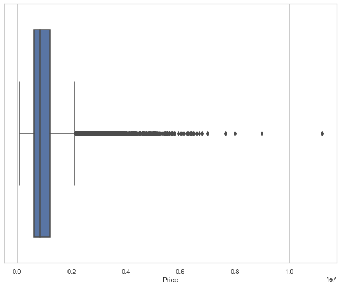

```python
# Plotting
import matplotlib.pyplot as plt
%matplotlib inline
import seaborn as sns #Seaborn is a Python data visualization library based on matplotlib
sns.set(style="whitegrid")
plt.figure(figsize=(10,8)) #Width, height in inches.
sns.boxplot(x='Price', data=clean_df, orient="h") #https://pythonbasics.org/seaborn-boxplot/  orient“v” | “h”, optional Orientation of the plot (vertical or horizontal).
```

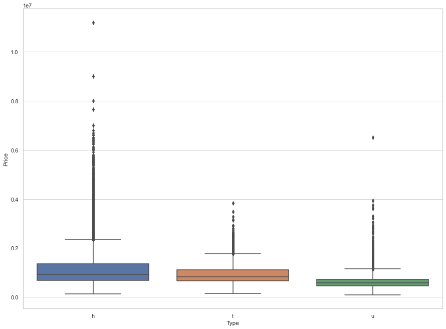

```python
# checking price for different types of house
plt.figure(figsize=(15,11))
sns.boxplot(x='Type', y='Price', data=df, orient="v")
```

```
Types of regions:  8
```

[output not shown]

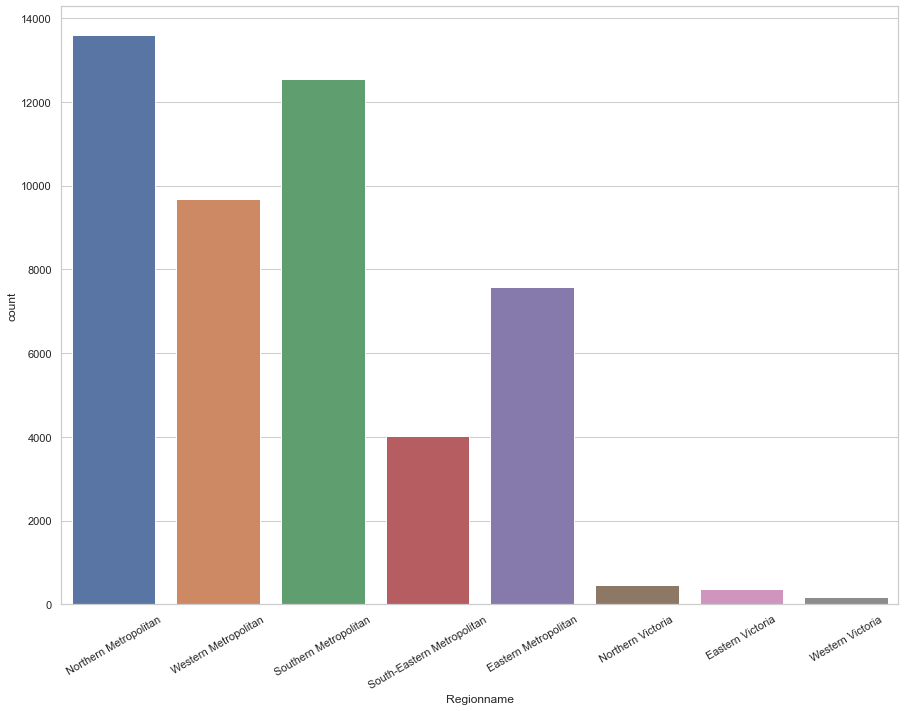

```python
# Exploring region-wise
regions = clean_df['Regionname']
print("Types of regions: ", len(set(regions)))

plt.figure(figsize=(15,11))
chart = sns.countplot(x='Regionname', data=clean_df) #Show the counts of observations in each categorical bin using bars.
chart.set_xticklabels(chart.get_xticklabels(), rotation=30) #rotation of the lables
```

## Skewed Distributions

When counting frequencies it is quite common to have many data points for a certain range of values and much less for the rest of the values. When this happens we say the distribution is not symmetric but skewed. The data distribution can be either positively skewed or negatively skewed.

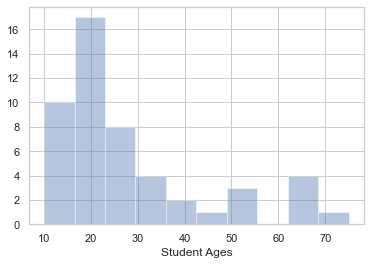

```python
# Positively skewed data
# Source: https://www.stefanfiott.com/machine-learning/descriptive-statistics-tutorial/
student_ages = pd.Series([15,19,18,14,13,
                          27,16,65,15,31,
                          22,15,24,22,51,
                          24,20,45,22,33,
                          24,27,18,66,15,
                          18,39,10,30,13,
                          19,28,53,28,65,
                          30,20,21,20,18,
                          20,23,18,41,52,
                          75,19,63,14,18],
                         name="Student Ages")
sns.distplot(student_ages, bins=10, kde=False); #depicts the variation in the data distribution, bins is the argument for matplotlib hist()
#kde: Whether to plot a gaussian kernel density estimate
```

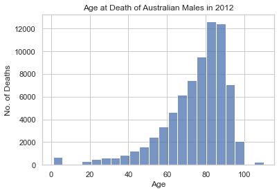

```python
# Negatively skewed data #pip install seaborn --upgrade
# Source: https://www.stefanfiott.com/machine-learning/descriptive-statistics-tutorial/
# Data for Age at Death of Australian Males in 2012. Ref: https://stats.stackexchange.com/a/122853
deaths_per_age = {1:565, 5:116, 10:69, 15:78, 20:319, 25:501, 30:633, 35:655, 40:848, 45:1226, 50:1633,
                  55:2459, 60:3375, 65:4669, 70:6152, 75:7436, 80:9526, 85:12619, 90:12455, 95:7113, 100:2104, 110:241}
sns.histplot(bins=len(list(deaths_per_age.keys())), x=list(deaths_per_age.keys()), weights=list(deaths_per_age.values()))
plt.title("Age at Death of Australian Males in 2012")
plt.ylabel("No. of Deaths")
plt.xlabel("Age")
```

# More on this

[Practical Machine Learning Project in Python on House Prices Data](https://www.hackerearth.com/practice/machine-learning/machine-learning-projects/python-project/tutorial/)

## Outliers

[figure not shown]

In statistics, an **outlier** is an observation point that is distant from other observations.

Outliers can have many causes, including:

```
- measurement or input error
- data corruption
- true outlier observation
```

## Why do we need to detect outliers

- The temptation to start building models on the given data, often ignores data exploration and analysing outliers.
- Outliers can impact the results of our analysis and statistical modeling in a drastic way.

[figure not shown]

## Outliers

*"Outliers are not necessarily a bad thing. These are just observations that are not following the same pattern as the other ones. But it can be the case that an outlier is very interesting. For example, if in a biological experiment, a rat is not dead whereas all others are, then it would be very interesting to understand why. This could lead to new scientific discoveries. So, it is important to detect outliers."*

```
                                                       - Pierre Lafaye de Micheaux, Author and Statistician
```

[5 Ways to Find Outliers in Your Data](https://statisticsbyjim.com/basics/outliers/#:~:text=Outliers%20are%20data%20points%20that,findings%20or%20distort%20real%20results.)

[Guidelines for Removing and Handling Outliers in Data](https://statisticsbyjim.com/basics/remove-outliers/)

[Handling outliers](https://www.rapidinsight.com/handle-outliers/)

## Data Privacy

*"Nothing about an individual should be learnable from the database that cannot be learned without access to the database."* — Tore Dalenius

- [Myki privacy de-railed](https://about.unimelb.edu.au/newsroom/news/2019/august/myki-privacy-de-railed-travellers-movements-and-identities-at-risk-by-public-release-of-anonymised-data)
- [Data Privacy in the age of Big Data](https://towardsdatascience.com/data-privacy-in-the-age-of-big-data-c28405e15508)
- [Rethinking Data Privacy: The Impact of Machine Learning](https://medium.com/luminovo/data-privacy-in-machine-learning-a-technical-deep-dive-f7f0365b1d60)

## Data privacy: Tips for Data Scientists

- Source: [Navigating the Data Privacy Maze: Tips for Data Scientists](https://towardsdatascience.com/navigating-the-data-privacy-maze-tips-for-data-scientists-c2f784969f29)
- Slides: [Navigating the Data Privacy Maze: Tips for Data Scientists](https://github.com/pydataedinburgh/meetups/blob/master/meetup-2018-07-25/katherine-jarmal-privacy-maze.pdf)
- [Australia Privacy Principles](https://www.oaic.gov.au/privacy/australian-privacy-principles/read-the-australian-privacy-principles)

[figure not shown]